# ASPE - Importation des tables de la base

Pascal Irz

Le 08 avril 2021

# Objet de la présentation

Le présent document vise à présenter comment importer les tables de la base ASPE sous la forme de `dataframe` R. Par la suite, il sera complété d’autres tutos sur l’utilisation des tables.

Le point de départ est un `dump`, sauvegarde de la base qui est réalisée chaque nuit au BRGM qui héberge la base de production. Il est prévu qu’un de ces `dump` soit mis à disposition à fréquence hebdomadaire pour être téléchargeable par les utilisateurs.

# Préparation du projet

De manière générale il est recommandé de travailler sous la forme de “projets R”. L’intérêt et la méthode sont développés dans les [supports de formation à R produits par le MTES](https://mtes-mct.github.io/parcours_r_socle_preparation_des_donnees/bien-commencer.html#cr%C3%A9er-un-projet-sous-rstudio-pour-vous-permettre-de-recencer-vos-travaux.).

Pour cet exemple on utilisera une des arborescences classiques :

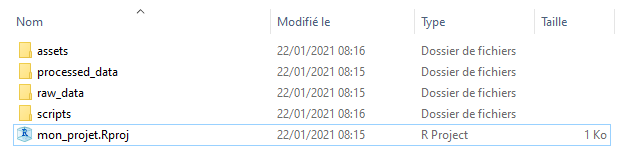

- Les données brutes sont stockées dans `raw_data`.
- Les sorties des traitements, y compris intermédiaires, sont dans `processed_data`.
- Les éléments d’illustration (logo, images, etc.) sont dans `assets`.
- Les scripts sont dans … `scripts`.

> À la racine on trouve le fichier projet `.Rproj`, sur lequel il convient de cliquer à chaque fois qu’on veut ouvrir une session de ce projet.

# Configuration machine

Pour installer le package {aspe} à partir de [Github](https://fr.wikipedia.org/wiki/GitHub) il faut une machine disposant des éléments suivants - préférentiellement à installer dans cet ordre :

1. Le logiciel R dans une version récente (>4.0) $\Rightarrow$ [télécharger](https://cran.r-project.org/bin/windows/base/R-4.0.3-win.exe)
2. L’IDE RStudio à peu près à jour $\Rightarrow$ [télécharger](https://download1.rstudio.org/desktop/windows/RStudio-1.3.1093.exe)
3. Les packages {devtools} et {roxygen2} (installables depuis Rstudio)
4. Rtools 40 64 bits $\Rightarrow$ [télécharger](https://cran.r-project.org/bin/windows/Rtools/)

# Chargement du package `{aspe}`

Une fois la machine configurée, le package est téléchargeable depuis Github :

```r
devtools::install_github("pascalirz/aspe")
```

Eventuellement cette commande vous retournera un message demandant de mettre à jour des packages. Acceptez au moins les mises à jour depuis le [CRAN](https://cran.r-project.org/).

# Activation du package `{aspe}`

… et des autres qui sont nécessaires pour exécuter les scripts.

```r
library(aspe)
library(tidyverse)
```

# Importation de la base

## Cas 1 : votre machine a 16Go de RAM ou plus

On importe la totalité de la base en une fois, ce qui est bien pratique. Dans la logique de l’arborescence du projet, le fichier de données - ici préalablement décompressé - est stocké dans le répertoire `raw_data`.

Cette opération prend une dizaine de minutes. Quand elle est terminée, des `Warning` sont affichés dans la console, mais pas d’erreurs. Une centaine de `dataframe` apparaissent dans l’onglet “Environnement” de RStudio.

```r
imp_importer_dump_sql(fichier_dump = "raw_data/aspe.sql")
```

L’import peut produire des messages d’avertissement (*Warning*) de ce type, qui n’indiquent pas de problème :

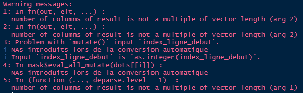

Pour éviter d’avoir à répéter cet import, on peut en sauvegarder le résultat au format `.RData` de façon à y accéder plus rapidement par la suite. Comme la table `mesure_individuelle` pèse à elle seule la moitié du volume de la base, on choisit de la conserver dans un fichier à part.

```r
save(mesure_individuelle, file = "processed_data/mei.RData")
rm(mesure_individuelle)
save.image(file = "processed_data/toutes_tables_aspe_sauf_mei.RData")
```

> NB : La fonction `importer_dump_sql()` accepte en entrée aussi bien le fichier compressé que décompressé.

## Cas 2 : votre machine a moins de 16Go de RAM

Avec une machine moins performante, la mémoire ne permettra pas de stocker simultanément le gros fichier texte du `dump` et les `dataframes`. Il faudra procéder en deux étapes. Une des tables, nommée `mesure_individuelle`, comprend à elle seule plus de lignes que la totalité des autres qui sont plus d’une centaine. Il s’agit de la traiter à part.

La première étape est de scinder le `dump` en deux parties qui seront stockées en format `.RData` :

- Le premier fichier contient les lignes du *dump* correspondant à la table `mesure_individuelle`.
- Le second contient le reste des lignes.

Ce découpage prend 5-10’.

```r
imp_scinder_dump(fichier_dump = "raw_data/aspe.sql.gz")
```

> NB : Cette opération peut être bloquée si le chemin d’accès est trop long, ce qui retourne un message d’erreur :

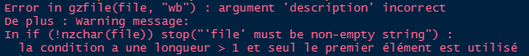

Dans ce cas, déplacez le `dump` pour accourcir le chemin d’accès.

Si ça a bien fonctionné on trouve dans le répertoire de destination (par défaut celui où se trouve le fichier du `dump`) les deux fichiers `.RData`.

[figure not shown]

> En cas de message d’erreur comprenant `Error in gzfile(file, "wb") : ...'`, la cause la plus probable est un mauvais chemin vers le fichier `dump`, ce qui ne devrait pas arriver avec l’organisation suggérée du projet.

Ensuite, on charge le fichier `.RData` souhaité.

```r
load(file = 'raw_data/lignes_autres_tables.RData')
```

Ce qui fait apparaître dans l’environnement un objet `lignes_autres_tables`.

Si l’on connaît les noms des tables dont on aura besoin, on les charge directement au moyen de l’argument `tables_a_extraire` en indiquant leur nom sous forme de vecteur.

```r
imp_tables_a_partir_des_lignes(lignes_dump = lignes_autres_tables,
                               tables_a_extraire = c("station", "facies"))
```

Si on ne les connaît pas, on peut les afficher …

```r
imp_extraire_noms_tables(lignes_dump = lignes_autres_tables)
```

… ou bien tout importer (environ 5’) pour effectuer le tri ultérieurement.

```r
imp_tables_a_partir_des_lignes(lignes_dump = lignes_autres_tables)
```

Comme cet import est un peu long, il y a intérêt à en sauvegarder le résultat dans le répertoire `processed_data`. L’import peut produire des messages d’avertissement (*Warning*) de ce type, qui n’indiquent pas de problème :

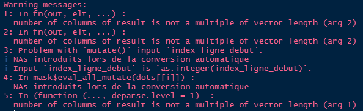

```r
rm(lignes_autres_tables)
save.image(file = "processed_data/toutes_tables_aspe_sauf_mei.RData")
```

Si l’on souhaite ne conserver qu’une partie des `dataframe` afin d’y voir plus clair, on peut effectuer une sélection avec la fonction `keep()` du package {gdata}, à installer si besoin.

```r
gdata::keep(operation, operation_description_peche, operation_donnees_environnementales, operation_ipr,
            station, point_prelevement, libelles, lot_poissons, parametres, parametres_globaux,
            ref_type_projection, prelevement_elementaire, ref_espece, ref_methode_estimation_poids,
            ref_protocole, ref_type_lot, ref_unite_hydrographique, ref_objectif, operation_objectif,
            sure = TRUE)

save.image(file = "processed_data/tables_selectionnees.RData")
```